# Graphics

May 7, 2019

# *Better Graphics with ggplot*

## Grammar of Graphics

- So far we have been using the “base” graphics of R.
- Base graphics can look good, but it takes some work.
- In this lesson, we’ll explore the `ggplot2` package, which is part of the tidyverse.
- `ggplot2` graphics look better “out of the box”, and the syntax follows the tidyverse philosopy.

## **$\Rightarrow$** Make a new RMarkdown document

1. Make sure your are in your `DataWorkshop` project. If not, switch to it.
2. In the *File* menu, choose *New File > RMarkdown…* and title a new document.
3. Clicking OK will open a new RMarkdown document with some boilerplate code. *Delete* everything below line 7.
4. *Save* the document as `tidyplots.Rmd` in the project directory `DataWorkshop`. After you save the file, it should appear in the *Files* tab, along with the file `DataWorkshop.Rproj`.

## **$\Rightarrow$** Load the tidyverse

```r
library(tidyverse)
```

## **$\Rightarrow$** look at `mpg` tibble

The `tidyverse` comes with a built-in tibble called `mpg`. To make it appear in the upper-right pane, type `View(mpg)` in the console. You can also just echo the name:

```r
mpg
```

```
## # A tibble: 234 x 11
##    manufacturer model displ  year   cyl trans drv     cty   hwy fl    class
##    <chr>        <chr> <dbl> <int> <int> <chr> <chr> <int> <int> <chr> <chr>
##  1 audi         a4      1.8  1999     4 auto… f        18    29 p     comp…
##  2 audi         a4      1.8  1999     4 manu… f        21    29 p     comp…
##  3 audi         a4      2    2008     4 manu… f        20    31 p     comp…
##  4 audi         a4      2    2008     4 auto… f        21    30 p     comp…
##  5 audi         a4      2.8  1999     6 auto… f        16    26 p     comp…
##  6 audi         a4      2.8  1999     6 manu… f        18    26 p     comp…
##  7 audi         a4      3.1  2008     6 auto… f        18    27 p     comp…
##  8 audi         a4 q…   1.8  1999     4 manu… 4        18    26 p     comp…
##  9 audi         a4 q…   1.8  1999     4 auto… 4        16    25 p     comp…
## 10 audi         a4 q…   2    2008     4 manu… 4        20    28 p     comp…
## # … with 224 more rows
```

## **$\Rightarrow$** Review Exercise

Use the tidyverse data transformations to create a list of all the auto manufacturers, along with the average city mpg of their vehicles, sorted from most fuel-efficient to least.

# *using GGplot*

## Data Visualization

Most of this lesson is adapted from [Chapter 3](https://r4ds.had.co.nz/data-visualisation.html) of *R for Data Science*.

## ggplot grammar

- `ggplot()` creates a blank graph.
- `ggplot(mpg)` associates the `mpg` data.
- `ggplot(mpg) + geom_point()` adds a scatterplot to the graph, but we need to specify what variables to use.
- `aes()` specifies which variables are represented by different properties of the graph (aesthetics).
- There are lots of different `geom`’s. You can add layers to the plot with `+`’s.

# *Scatterplots*

## ggplot scatterplot

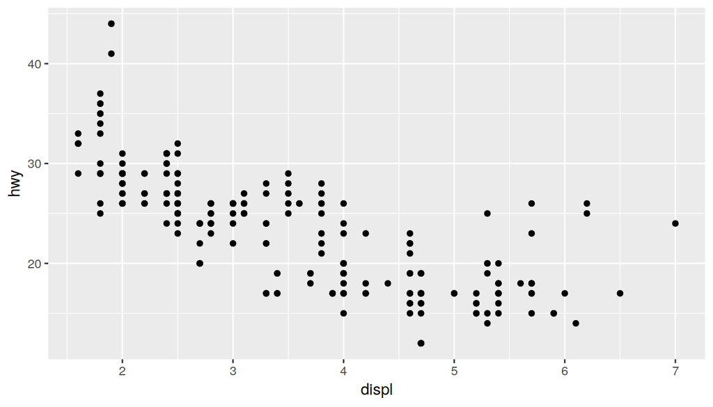

```r
ggplot(mpg) + geom_point(aes(x=displ, y=hwy))
```

## Coloring factors

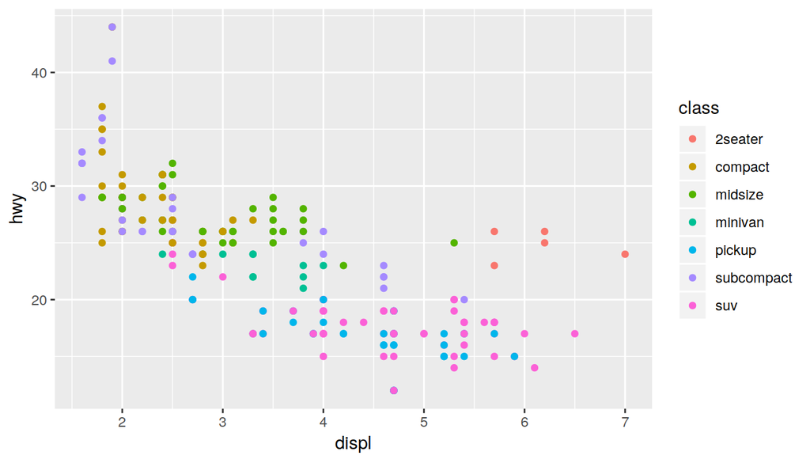

```r
ggplot(mpg) + geom_point(aes(x=displ, y=hwy, color = class))
```

## Sizing dots

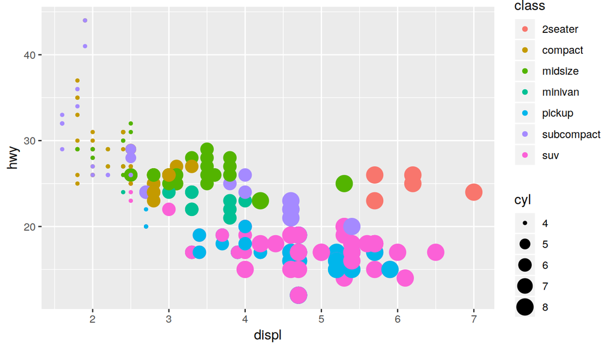

```r
ggplot(mpg) + geom_point(aes(x=displ, y=hwy, color = class, size=cyl))
```

## Manual settings

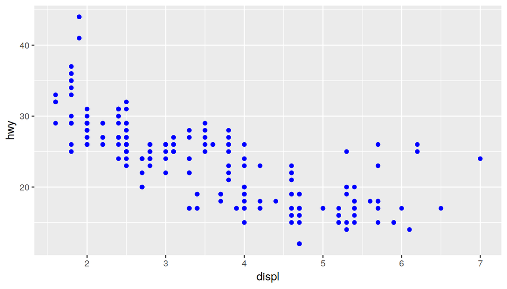

```r
ggplot(mpg) + geom_point(aes(x=displ, y=hwy), color = "blue")
```

## Manual settings (wrong: why?)

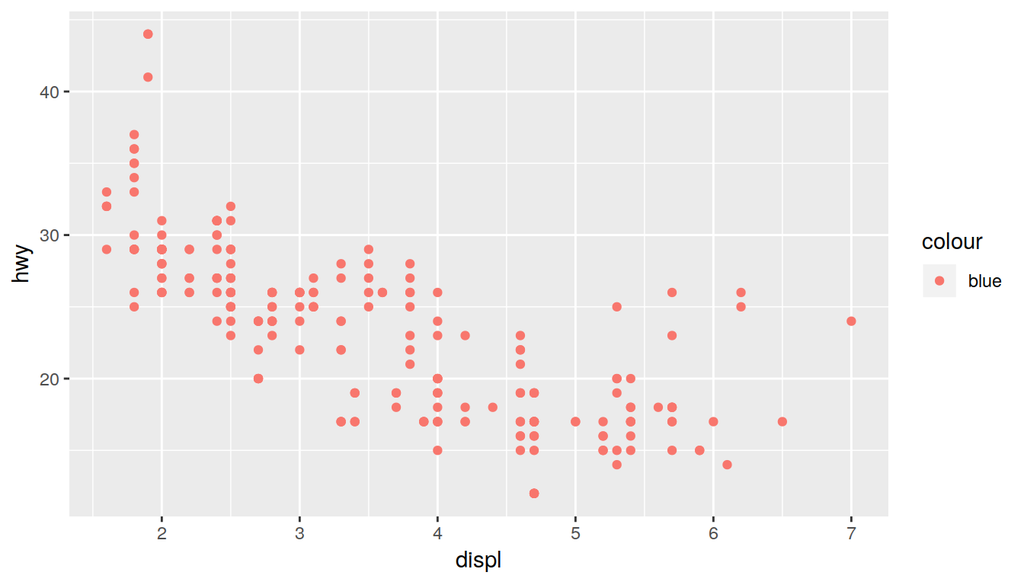

```r
ggplot(mpg) + geom_point(aes(x=displ, y=hwy, color = "blue"))
```

## **$\Rightarrow$** Scatterplot exercises

1. Map a continuous variable to `color`, `size`, and `shape`.
2. Map the same variable to multiple aesthetics.
3. What does the `stroke` aesthetic do? What shapes does it work with? (Hint: use `vignette("ggplot2-specs")`.)
4. What happens if you map an aesthetic to something other than a variable name, like `aes(color = displ < 5)`? Note, you’ll also need to specify `x` and `y`.

# *Adding geometries*

## Facet Grid

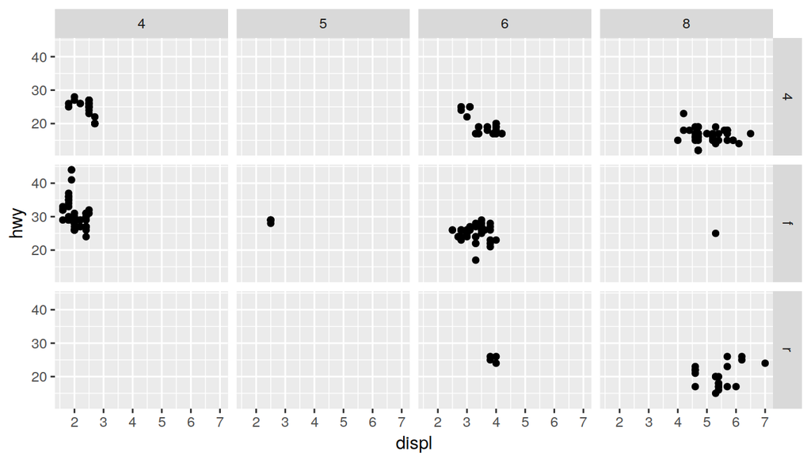

```r
ggplot(data = mpg) +
  geom_point(mapping = aes(x = displ, y = hwy)) +
  facet_grid(drv ~ cyl)
```

## Facet Grid (collapsed)

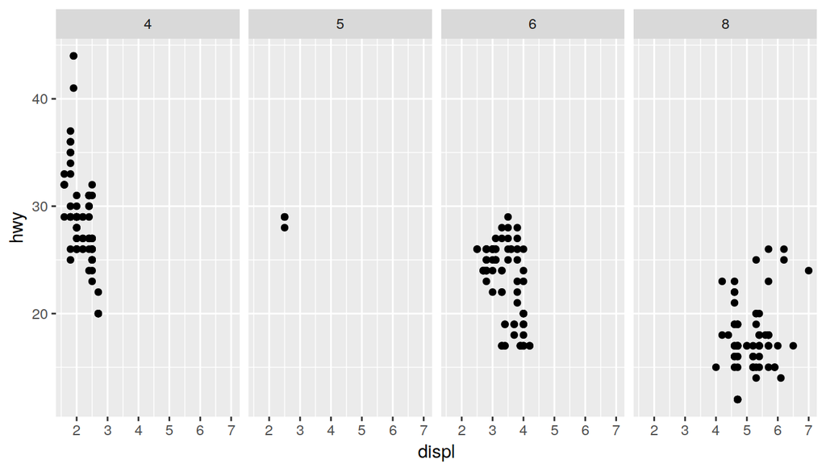

```r
ggplot(data = mpg) +
  geom_point(mapping = aes(x = displ, y = hwy)) +
  facet_grid(. ~ cyl)
```

## Facet Wrap

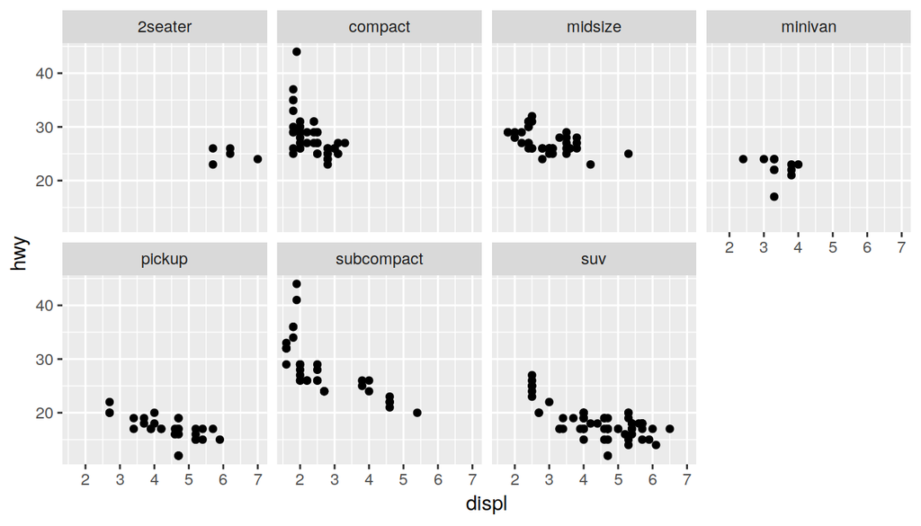

```r
ggplot(data = mpg) +
  geom_point(mapping = aes(x = displ, y = hwy)) +
  facet_wrap(~ class, nrow = 2)
```

## **$\Rightarrow$** Geometry exercises

1. Read `?facet_wrap`. What does `nrow` do? What does `ncol` do? Why doesn’t `facet_grid()` have these arguments?